# M2: Introduction to Hidden Markov Models

## 6. Further Applications

While the 3-state model was selected as the best model, it is unclear what this third state is? As a result and even though this model was selected based on AIC, adding this additional is of limited value.

Similar to activities demonstrated above, we will encode the behavioral states of the 2-state model with the covariate for time of day to our original dataframe. By doing so, we can calculate how much time animals remain in particular behavioral states, compare differences in animal behavior between study areas, or identify areas that are associated with certain behavioral states. This could be particularly helpful if your goal was to separate the data to create seasonal home ranges where animals are mostly in a residential movement state.

Here, we filter the data by state behaviors and plot each behavior separately. We’ll follow the same procedure that we demonstrated above. The output shows some clear areas where one of the wildebeest (Sawani) spent large periods in a encamped state, but there are quite a few points where these areas overlap. This kind of approach could be explored for your data/other species.

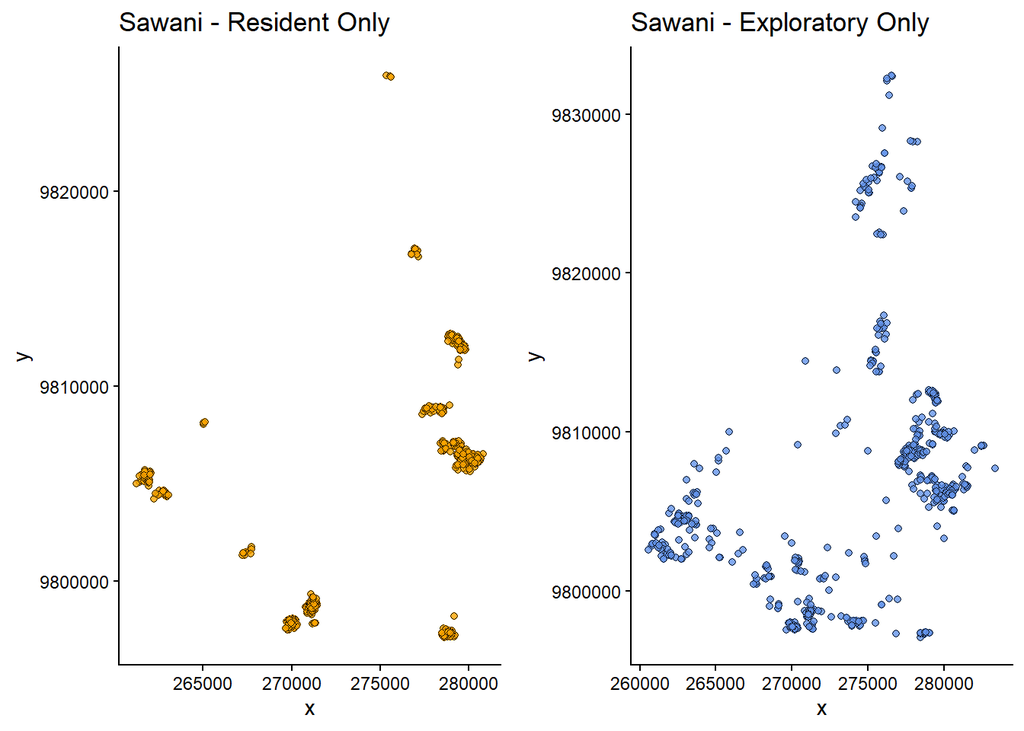

```r
# Encode the behaviors using the Viterbi algorithm
# NOTE that we are mapping the 2 state model here
WB.tod.states <- viterbi(WB.tod.2state)

# add to the dataset and remove some extra fiels
WB.states <- WB.move %>%
  mutate(state = as.factor(WB.tod.states)) %>%
  # Remove some fields to make dataset smaller
  select(-c(step,angle,temp,hour))

# Create plot of Resident behaviors (State 1) for 1 individual
WB.State1 <- WB.states %>%
  filter(state == 1 & ID == "Sawani") %>%
  ggplot(aes(x = x*1000,
             y = y*1000,
             col = state,
             fill = state)) +
  #geom_path(alpha = 0.5) +
  geom_point(shape = 21,
             alpha = 0.8,
             col = "black",
             show.legend = FALSE) +
  scale_color_manual(values = "orange") +
  scale_fill_manual(values = "orange") +
  theme_classic() +
  labs(x = "x",
       y = "y",
       title = "Sawani - Resident Only")

# Create plot of exploratory behaviors (State 2) for 1 individual
WB.State2 <- WB.states %>%
  filter(state == 2 & ID == "Sawani") %>%
  ggplot(aes(x = x*1000,
             y = y*1000,
             col = state,
             fill = state)) +
  #geom_path(alpha = 0.5) +
  geom_point(shape = 21,
             alpha = 0.8,
             col = "black",
             show.legend = FALSE) +
  scale_color_manual(values = "cornflowerblue") +
  scale_fill_manual(values = "cornflowerblue") +
  theme_classic() +
  labs(x = "x",
       y = "y",
       title = "Sawani - Exploratory Only")

# Use the cowplot package to combine these plots next to each other.
two_plots <- cowplot::plot_grid(WB.State1,
                                WB.State2,
                                ncol = 2,
                                rel_widths = c(1, 1))

# Show the plots
two_plots
```

```r
# Save the plots
ggsave(plot = two_plots,
       filename = "Output/sawani_residencelocations.tiff",
       units = "in",
       width = 6.5,
       height = 4)
```

# Exercise: Apply to your own data

Now that you have learned the basics, adapt the code and fit a few models to your own dataset. Following this exercise, all that you need is a properly formatted data.frame with unique IDs and GPS coordinates. Make sure to first assess if your data represent a regular trajectory and refer to previous lectures to correct this item, if necessary. Verify that your dataset are arranged in order. Experiment with different model structures and distributions.

**Useful questions to answer for your own dataset:**

- Does your data contain a parameter (or two) that could be integrated in your modeling framework to explain differences in behavior?
- What other covariates could be added that would warrant further investigate?
- How much movement do you see when decoding for different behavioral states?

As an additional/practical exercise, it can be useful to collect GPS data on yourself so that you can keep a log of your behaviors and determine if you can recover these behaviors with a model. Try the following:

1. Download a GPS tracking app to your phone (e.g., GeoTracker).
2. Spend a few hours tracking yourself, recording the precise time you sit down and rest, when you stand and walk around, and when you go for a run or ride your bike. These represent very different behavioral states.
3. Practice downloading the data from your phone and uploading the dataset into [R](https://cran.r-project.org/).
4. Clean the data as appropriate to fit a hidden Markov model of your behaviors.
5. Experiment with how the data are collected to evaluate how your ability to detect these three behaviors (resting, walking, running) changes with the resolution of your GPS track (i.e., 5-minute interval versus a 1-hour temporal interval).

## Key functions reference

| Function | Package | Purpose |
| --- | --- | --- |
| `right_join()`, `left_join()` | `dplyr` | Join two datasets, keeping all rows from the right table |
| `arrange()` | `dplyr` | Sort rows by specified variables. |
| `hour()` | `lubridate` | Extract hour from datetime |
| `prepData()` | `momentuHMM` | Prepare movement data for HMM fitting (compute steps, angles, covariates) |
| `fitHMM()` | `momentuHMM` | Fit hidden Markov models to movement data |
| `viterbi()` | `momentuHMM` | Decode most likely state sequence |
| `stateProbs()` | `momentuHMM` | Compute state probabilities for each observation |
| `plotStates()` | `momentuHMM` | Plot state sequences |
| `plotStationary()` | `momentuHMM` | Plot stationary state probabilities vs covariates |
| `cosinor()` | `momentuHMM` | Build cyclic covariate (e.g., diel cycle) |

*Next:* **Day 5 — Behavior Analysis Pt 2** — Now we will take one additional step and fit a HMM to accelerometer data.